# Practical Machine Learning project - Coursera Data Science specialization

Danut Bancea

Saturday, October 26, 2014

# Introduction

Using the data collected from a personal activity preditc which type of activity and exercise was completed. The type of execise is in the classe variable and all the other can be used to predict teh activity.

# Data source

The csv format file were downloaded from teh coursera website and saved in the git hub repository on local computer and also on the on the git hub web. There are two type of data: pml-training.csv - which will be used for model creation and validation pml-testing.csv - test data to generate the 20 test cases and

Web link for the csv data source files: https://d396qusza40orc.cloudfront.net/predmachlearn/pml-training.csv https://d396qusza40orc.cloudfront.net/predmachlearn/pml-testing.csv

The original data came from the next link: http://groupware.les.inf.puc-rio.br/har

# Data exploratory and cleaning

## Load required libraries

```r
library(caret);
library(randomForest);
```

## Data load

Load the csv training file and explore the data

```r
setwd('D:\\cursuri\\PracticalMachineLearning\\Project\\pml');
pml <- read.csv('pml-training.csv', na.strings=c("NA",""));
pml_test <- read.csv('pml-testing.csv', na.strings=c("NA",""));
```

Explore the data dimensions.

```r
dim(pml);
```

```
## [1] 19622   160
```

For the next processing part to find which variables are more usefull in modelling using correlation and PCA we need to exclude the columns which have NA values since. The requirement for correlation and PCA is to have all teh columns in numeric format.

```r
pml <- pml[, colSums(is.na(pml)) == 0];
dim(pml);
```

```
## [1] 19622    60
```

We analyze again the new subset of data based on data type to find which columns will be deleted.

```r
sapply(pml, class);
```

```
##                    X            user_name raw_timestamp_part_1
##            "integer"             "factor"            "integer"
## raw_timestamp_part_2       cvtd_timestamp           new_window
##            "integer"             "factor"             "factor"
##           num_window            roll_belt           pitch_belt
##            "integer"            "numeric"            "numeric"
##             yaw_belt     total_accel_belt         gyros_belt_x
##            "numeric"            "integer"            "numeric"
##         gyros_belt_y         gyros_belt_z         accel_belt_x
##            "numeric"            "numeric"            "integer"
##         accel_belt_y         accel_belt_z        magnet_belt_x
##            "integer"            "integer"            "integer"
##        magnet_belt_y        magnet_belt_z             roll_arm
##            "integer"            "integer"            "numeric"
##            pitch_arm              yaw_arm      total_accel_arm
##            "numeric"            "numeric"            "integer"
##          gyros_arm_x          gyros_arm_y          gyros_arm_z
##            "numeric"            "numeric"            "numeric"
##          accel_arm_x          accel_arm_y          accel_arm_z
##            "integer"            "integer"            "integer"
##         magnet_arm_x         magnet_arm_y         magnet_arm_z
##            "integer"            "integer"            "integer"
##        roll_dumbbell       pitch_dumbbell         yaw_dumbbell
##            "numeric"            "numeric"            "numeric"
## total_accel_dumbbell     gyros_dumbbell_x     gyros_dumbbell_y
##            "integer"            "numeric"            "numeric"
##     gyros_dumbbell_z     accel_dumbbell_x     accel_dumbbell_y
##            "numeric"            "integer"            "integer"
##     accel_dumbbell_z    magnet_dumbbell_x    magnet_dumbbell_y
##            "integer"            "integer"            "integer"
##    magnet_dumbbell_z         roll_forearm        pitch_forearm
##            "numeric"            "numeric"            "numeric"
##          yaw_forearm  total_accel_forearm      gyros_forearm_x
##            "numeric"            "integer"            "numeric"
##      gyros_forearm_y      gyros_forearm_z      accel_forearm_x
##            "numeric"            "numeric"            "integer"
##      accel_forearm_y      accel_forearm_z     magnet_forearm_x
##            "integer"            "integer"            "integer"
##     magnet_forearm_y     magnet_forearm_z               classe
##            "numeric"            "numeric"             "factor"
```

Based on data output for data type we will delete the next columns from the data set: X, user_name, raw_timestamp_part_1, raw_timestamp_part_2, cvtd_timestamp, new_window.

```r
col_drop <- c('X','user_name', 'raw_timestamp_part_1', 'raw_timestamp_part_2', 'cvtd_timestamp', 'new_window');
pml <- pml[, !(names(pml) %in% col_drop) ];
dim(pml);
```

```
## [1] 19622    54
```

## Data partition

We will partition the data in two sets: training which will have 70% of the training data set and validation with the remaining of 30% of the data.

```r
in_train <- createDataPartition(pml$classe, p=0.70, list=FALSE);
pml_train <- pml[in_train,];
pml_valid <- pml[-in_train,];
```

# Data analysis

## Principal Components Analysis

```r
col_ignore <- c('classe');
preProc_PCA <- preProcess(pml_train[, !names(pml_train) %in% col_ignore], method="pca", tresh=0.975);
pml_train_PCA <- predict(preProc_PCA, pml_train[, !names(pml_train) %in% col_ignore] );
pml_valid_PCA <- predict(preProc_PCA, pml_valid[, !names(pml_train) %in% col_ignore] );
```

# Data modeling

For data modelling the random forest is used to calcualte the new data model.

```r
pml_modelFit_PCA <- train(pml_train$classe ~ ., method="rf", data=pml_train_PCA);
```

Calculate the confusion matrix and display the result.

```r
pml_PCA_confusion <- confusionMatrix(pml_valid$classe, predict(pml_modelFit_PCA, pml_valid_PCA));
pml_PCA_confusion;
```

```
## Confusion Matrix and Statistics
##
##           Reference
## Prediction    A    B    C    D    E
##          A 1666    3    5    0    0
##          B   19 1102   15    0    3
##          C    1   12  998   12    3
##          D    2    2   36  923    1
##          E    0    2    7    6 1067
##
## Overall Statistics
##
##                Accuracy : 0.978
##                  95% CI : (0.974, 0.982)
##     No Information Rate : 0.287
##     P-Value [Acc > NIR] : <2e-16
##
##                   Kappa : 0.972
##  Mcnemar's Test P-Value : NA
##
## Statistics by Class:
##
##                      Class: A Class: B Class: C Class: D Class: E
## Sensitivity             0.987    0.983    0.941    0.981    0.993
## Specificity             0.998    0.992    0.994    0.992    0.997
## Pos Pred Value          0.995    0.968    0.973    0.957    0.986
## Neg Pred Value          0.995    0.996    0.987    0.996    0.999
## Prevalence              0.287    0.190    0.180    0.160    0.182
## Detection Rate          0.283    0.187    0.170    0.157    0.181
## Detection Prevalence    0.284    0.194    0.174    0.164    0.184
## Balanced Accuracy       0.993    0.988    0.967    0.986    0.995
```

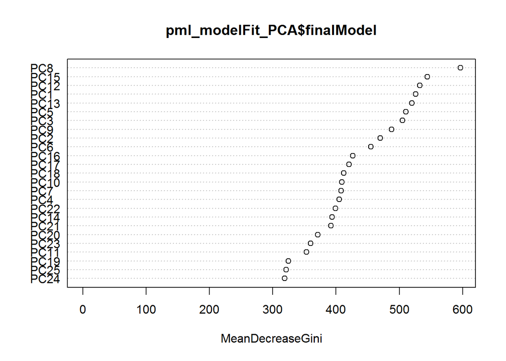

```r
varImpPlot(pml_modelFit_PCA$finalModel, sort=TRUE)
```

# Conclusion

The variables selection and the modele selected, random forest, and with 70% training data and 30% validation data split, the fitted model have an accuracy of 97.8%. If more accuracy is required the initial selection of teh variables has to be different, and more data exploratory tests will berequired to find which varisbles and records can be kept to improve the accuracy.

# Predicted results and files generation

Delete the columns not used in prediction from the testing data set.

```r
col_valid_name <- names(pml);
pml_test <- pml_test[,names(pml_test) %in% col_valid_name];
dim(pml_test);
```

```
## [1] 20 53
```

```r
dim(pml);
```

```
## [1] 19622    54
```

Use PCA to select the columns which will be used in testing prediction, predict the test values and display the predicted values.

```r
col_ignore <- c('classe');
pml_test_PCA <- predict(preProc_PCA, pml_test[, !names(pml_test) %in% col_ignore] );
pred_test <- predict(pml_modelFit_PCA, newdata=pml_test_PCA);
```

Generate the answer files for submission.

```r
pml_write_files = function(x){
     n = length(x)
     for(i in 1:n){
         filename = paste0("problem_id_",i,".txt")
         write.table(x[i],file=filename,quote=FALSE,row.names=FALSE,col.names=FALSE)
     }
};
pml_write_files(pred_test);
```